# Team 2 - Lab 1

Forecasting with ARIMA and ETS models

Matheus de Barros, Lilac Hong, Mary Orrand

April 22, 2025

# Data

We will focus on the monthly data (`chinook.month`).

```r
# Create a date column and safely log-transform metric.tons
chinook.month <- chinook.month %>%
  mutate(Date = as.Date(paste(Year, Month, "01", sep = "-"), format = "%Y-%b-%d"),
    log.metric.tons = ifelse(metric.tons <= 0, NA, log(metric.tons)))

# Monthly data summed across states
chinook.month.wc <- chinook.month %>%
  group_by(Year, Month) %>%
  summarise(
    metric.tons = sum(metric.tons, na.rm = TRUE),
    .groups = "drop"
  ) %>%
  mutate(
    Date = as.Date(paste(Year, Month, "01", sep = "-"), format = "%Y-%b-%d"),
    log.metric.tons = ifelse(metric.tons <= 0, NA, log(metric.tons))
  ) %>%
  arrange(Date)

# Create time series object
month_wc_ts <- ts(chinook.month.wc$log.metric.tons, start = c(1990, 1), frequency = 12)
```

# Overview

# Diagnostics and preliminary exploration (Lilac)

## Plot the data

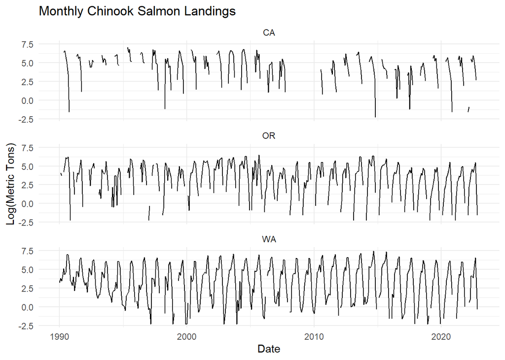

```r
# Plot with facets by State
ggplot(chinook.month, aes(x = Date, y = log.metric.tons)) +
  geom_line() +
  facet_wrap(~ State, ncol = 1) +  # 3 panels vertically
  labs(title = "Monthly Chinook Salmon Landings",
       x = "Date",
       y = "Log(Metric Tons)") +
  theme_minimal()
```

California (CA) exhibits strong signs of non-stationarity. There are large gaps in the data, including an extended period of missing values around 2008–2010. The means are higher in the early years and lower in more recent years, with noticeable inconsistencies in variance.

Oregon (OR) also appears to be non-stationary, though some seasonality is evident. The overall mean shows a slight downward trend over time.

Washington (WA) appears to be the most stable of the three. A clear seasonal pattern is present, and both the mean and variance remain relatively consistent over time, especially in comparison to CA and OR.

Next, examine the monthly data aggregated across all states, which will serve as our primary data source for later analysis.

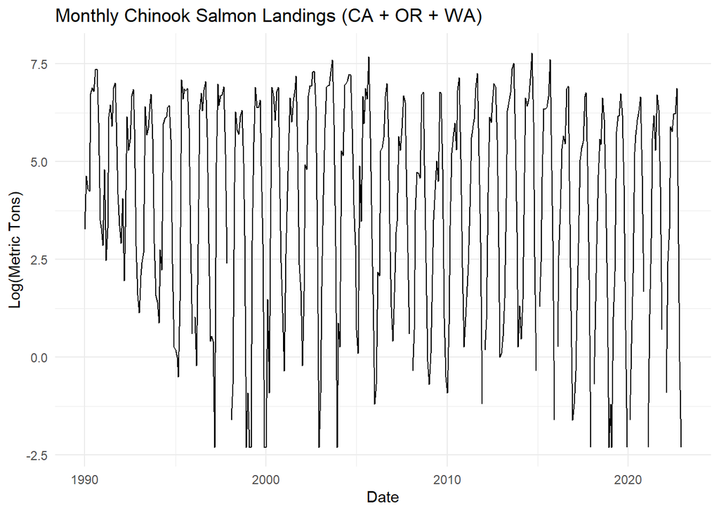

```r
# Plot aggregated data
ggplot(chinook.month.wc, aes(x = Date, y = log.metric.tons)) +
  geom_line() +
  labs(title = "Monthly Chinook Salmon Landings (CA + OR + WA)",
       x = "Date",
       y = "Log(Metric Tons)") +
  theme_minimal()
```

After aggregating the data across states, the resulting time series does not appear to be strictly stationary, though it shows greater stationarity from around 2000 onward. A strong and consistent seasonal pattern is clearly visible. The early 1990s are characterized by higher variability and a potential decline in the mean. From the 2000s forward, there is no obvious long-term upward or downward trend.

One concern is the handling of missing (`NA`) values — currently, they are treated as zeros during addition. This could exaggerate seasonal differences, as a significant portion of the missing data occurs between November and April, especially in CA data. While this may not be highly impactful (since Chinook landings are likely near zero in winter months anyway), it’s something to be mindful of moving forward.

## Use ACF and PACF

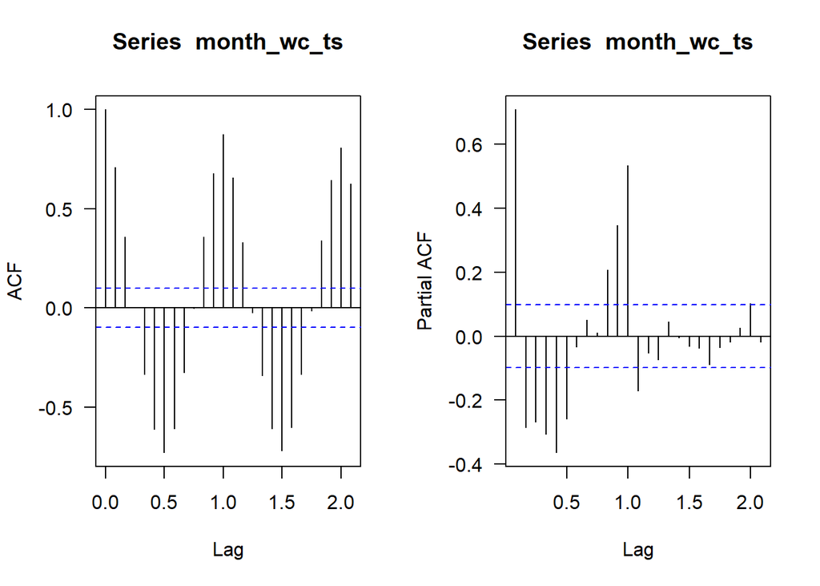

```r
# ACF and PACF plots
par(mfrow=c(1,2))
acf(month_wc_ts, na.action = na.pass, las = 1)
pacf(month_wc_ts, na.action = na.pass, las = 1)
```

The ACF plot shows clear positive spikes around lags 1 and 2 (about 12 and 24 months), along with strong negative spikes near lags 0.5 and 1.5 (around 6 and 18 months). Pattern keeps repeating and does not die out quickly, suggesting a non-stationary series with a clear annual seasonality.

The PACF plot shows one large positive spike at the 1-month lag, with smaller but noticeable spikes up to lag 11, and then another big spike at lag 12, after which the spikes quickly drop off. This suggests that using an AR(1) model might be good enough for capturing the non-seasonal part of the data.

### Decomposition

Next, I will decompose the time series. Since `stl` cannot handle missing values, and the NAs in the data are sparse and not clustered, interpolation is a safe and appropriate solution. Therefore, I will fill the missing values using linear interpolation with `zoo::na.approx()`.

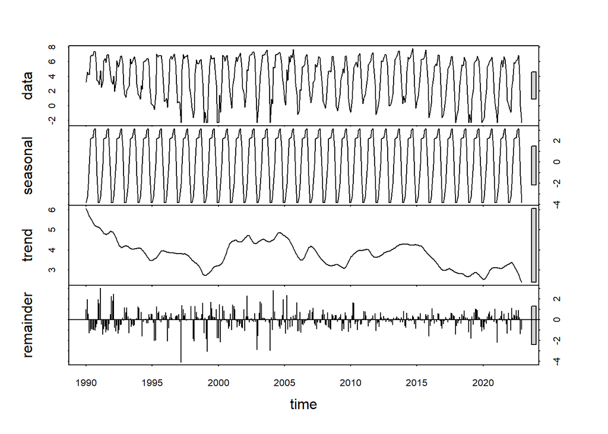

```r
# Fill missing values with linear interpolation
month_wc_ts_filled <- na.approx(month_wc_ts)
decomp_WA <- stl(month_wc_ts_filled, s.window = "periodic")
plot(decomp_WA)
```

The additive decomposition shows that the time-series is dominated by a strong seasonal component that repeats the same saw-tooth shape every year. The underlying trend drifts downward overall, with notable upswings in the mid-2000s and again in the mid-2010s. The remainder series shows no obvious autocorrelation, recurring cycles, or variance that change with time - mostly white noise, with a few spikes.

## Test for stationarity

```r
ndiffs(month_wc_ts) # non-seasonal stationary
```

```
## [1] 0
```

```r
nsdiffs(month_wc_ts) # seasonal stationary
```

```
## [1] 1
```

It appears that no differencing is required for the non-seasonal component. However, the seasonal component is non-stationary and requires one order of differencing.

# Question, Method, Results, and Discussion

## Question 1 (Matheus)

How does the length of the training data affects resulting forecasts from ARIMA models?

### The methods

Different ARIMA models were fitted to multiple sets of the monthly data on chinook landings split into varying intervals, namely 5, 10, 15, 20, and 25 years of data. Then, forecasts based on each of the training datasets were created and compared with the observed values from the raw dataset.

### Formatting the data

```r
chinook.month$Month2 = as.numeric(as.factor(chinook.month$Month))
```

### Splitting the data into different sets of training and testing data with varying lengths

```r
chinook.month.wc = chinook.month %>%
  group_by(Year, Month) %>%
  summarise(
    metric.tons = sum(metric.tons, na.rm = TRUE),
    .groups = "drop"
  ) %>%
  mutate(
    Date = as.Date(paste(Year, Month, "01", sep = "-"), format = "%Y-%b-%d"),
    log.metric.tons = log(metric.tons)
  ) %>%
  arrange(Date)

dat = chinook.month %>%
    mutate(
    lnreturns = log.metric.tons,
    year = Year,
    month = match(Month, month.abb)
  ) %>%
  select(year, month, lnreturns)

month_ts = ts(dat$lnreturns, start = c(1980, 1), frequency = 12)

# Create test data with different ts lenghts
ts_lengths  = c(5,10,15,20,25)
month_train = list()
month_test  = list()
for (i in 1:length(ts_lengths)) {

  month_train[[i]] = window(month_ts,
                            start = c(1980, 1),
                            end   = c(1980 + ts_lengths[i], 12))

  month_test[[i]]  = window(month_ts,
                            start = c(1980 + ts_lengths[i] + 1, 1),
                            end = c(2019, 12))

}
```

### Fitting models using ‘auto.arima’

```r
# Fit ARIMA models to all time series
train_models = list()
for (i in 1:length(month_train)) train_models[[i]] = auto.arima(month_train[[i]])

# Compare forecast against test data
fr = list()
for (i in 1:length(month_train)) fr[[i]] = forecast(train_models[[i]], h = length(month_test[[i]])*2)

plots = list()
for (i in 1:length(month_train)) {
  plots[[i]] = autoplot(fr[[i]]) +
    geom_point(aes(x = x, y = y), size = 0.5, data = fortify(month_test[[i]])) +
    labs(title = paste("Number of years =", ts_lengths[i]), x = "Year", y = "Log(mt)") +
    theme_minimal()
}
```

### Discussion

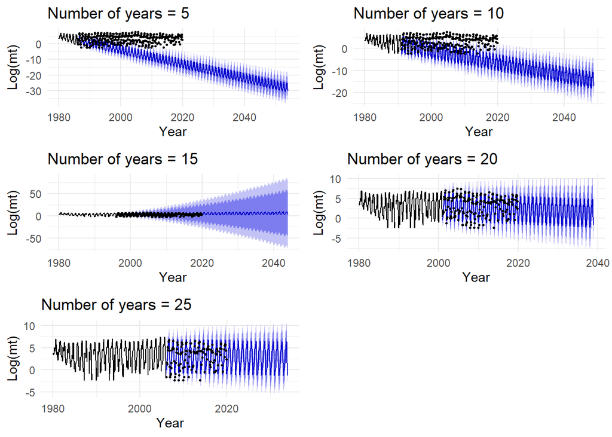

```r
ggarrange(plotlist = plots, ncol = 2, nrow = 3)
```

## Question 2 (Mary)

How does the structure of an ARIMA model affect its ability to forecast salmon landings when trained on 25 years of data? Which ARIMA model structure best captures long-term patterns in Chinook salmon landings, and why?

After discussing with my teammates and reviewing best results, I decided to follow Matheus’ approach of training on a 25-year dataset, since our findings showed this time frame produced the most reliable forecasts. For my section of the lab, I will use the same framework for consistency across our analyses. My goal was to define a 25-year training set (1980–2004) and use it to fit multiple ARIMA models — starting with an automatically selected model using `auto.arima()`, followed by two manually specified ARIMA models. This allowed me to compare how model structure impacts forecast performance when applied to monthly Chinook salmon landings.

```r
# 25-year training: Jan 1980 – Dec 2004
train_25 <- window(month_ts, start = c(1980, 1), end = c(2004, 12))

# Test: Jan 2005 – Dec 2022 (or last available year)
test_25 <- window(month_ts, start = c(2005, 1), end = c(2022, 12))
```

In the following section, I fit three different ARIMA models to the 25-year training data from above: - The first is chosen automatically using the auto.arima() function, which finds the best model based on AIC. - The second is a manually defined ARIMA(1,1,1) model, which includes both AR and MA components with one difference. - The third is ARIMA(2,0,0), a manually specified model with more autoregressive terms but no differencing.

These manual models are included to test whether expert-chosen structures can outperform the automatically selected model.

```r
# Fit auto ARIMA to 25-year training data
mod_auto_25 <- auto.arima(train_25)

# Manual ARIMA(1,1,1)
mod_manual_111 <- Arima(train_25, order = c(1,1,1))

# Manual ARIMA(2,0,0)
mod_manual_200 <- Arima(train_25, order = c(2,0,0))
```

This section generates forecasts from all three fitted models for the same length as the test set.

The output will be used to visualize and evaluate each model’s ability to accurately forecast future events.

```r
# Forecast all models for the length of the test set
fc_auto_25   <- forecast(mod_auto_25, h = length(test_25))
fc_manual_111 <- forecast(mod_manual_111, h = length(test_25))
fc_manual_200 <- forecast(mod_manual_200, h = length(test_25))
```

This plot shows the forecast from the auto ARIMA model overlaid with the actual observed data from the test period.The shaded area represents the model’s forecast uncertainty.This visual comparison helps us assess how closely the model captures the true pattern of Chinook landings.

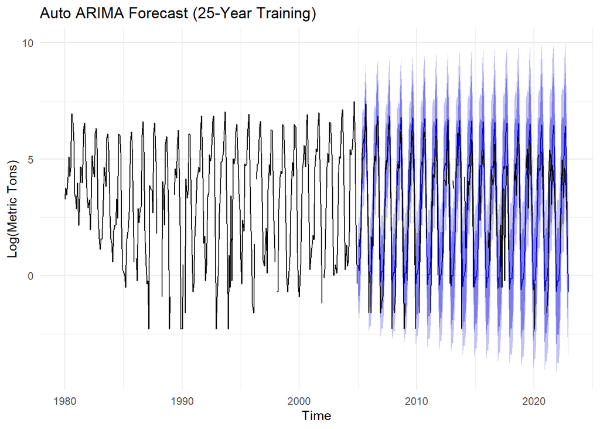

```r
autoplot(fc_auto_25) +
  autolayer(test_25, series = "Observed", color = "black") +
  ggtitle("Auto ARIMA Forecast (25-Year Training)") +
  ylab("Log(Metric Tons)") +
  theme_minimal()
```

This plot shows the forecast from the manual ARIMA(1,1,1) model, with the test data overlaid in black. This model assumes moderate memory and differencing, and is commonly used in many forecasting applications.Comparing this plot to the auto model helps us evaluate whether a standard manual model performs better or worse.

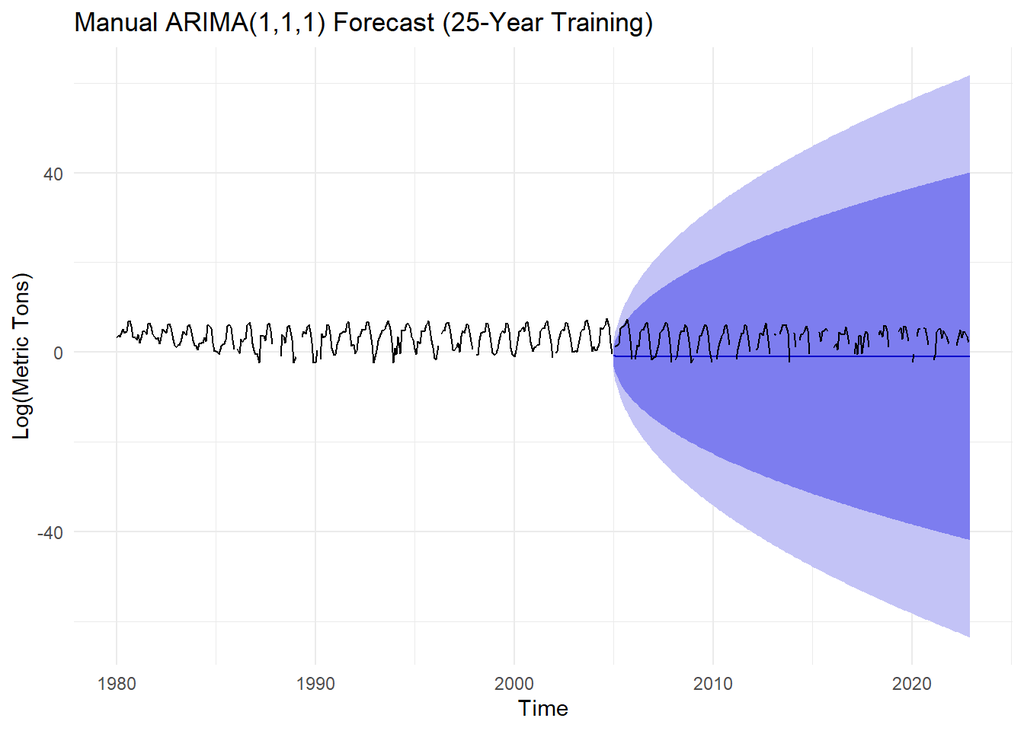

```r
autoplot(fc_manual_111) +
  autolayer(test_25, series = "Observed", color = "black") +
  ggtitle("Manual ARIMA(1,1,1) Forecast (25-Year Training)") +
  ylab("Log(Metric Tons)") +
  theme_minimal()
```

This plot shows the forecast from the manual ARIMA(2,0,0) model, which relies more heavily on autoregressive terms. There is no differencing in this model, so we are testing how well the model can handle trend-like behavior directly. Again, the black line shows actual test data, providing a basis for visual evaluation.

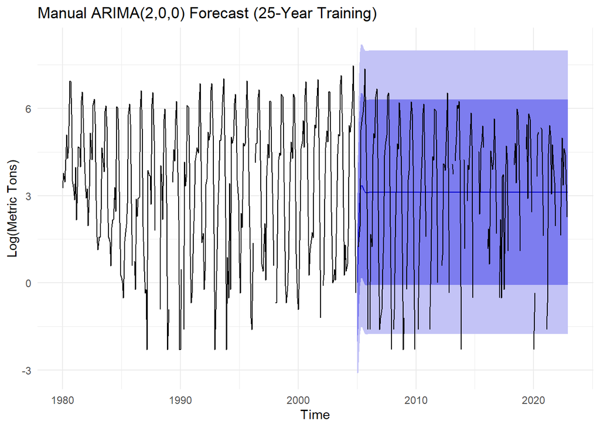

```r
autoplot(fc_manual_200) +
  autolayer(test_25, series = "Observed", color = "black") +
  ggtitle("Manual ARIMA(2,0,0) Forecast (25-Year Training)") +
  ylab("Log(Metric Tons)") +
  theme_minimal()
```

This chunk calculates a set of forecast accuracy metrics for each model using the test set as the reference. These include Root Mean Square Error (RMSE), Mean Absolute Error (MAE), and MASE, among others.Lower values indicate better predictive performance. The results are combined into a single table so we can directly compare which model forecasted the test data most accurately.

```r
# Compare forecast accuracy using test data
acc_auto   <- accuracy(fc_auto_25, test_25)
acc_111    <- accuracy(fc_manual_111, test_25)
acc_200    <- accuracy(fc_manual_200, test_25)

# Combine into a data frame for easy comparison
accuracy_results <- rbind(
  `Auto ARIMA` = acc_auto,
  `Manual ARIMA(1,1,1)` = acc_111,
  `Manual ARIMA(2,0,0)` = acc_200
)

accuracy_results
```

```
##                       ME     RMSE       MAE  MPE MAPE      MASE          ACF1
## Training set -0.02538361 0.947600 0.6347845  NaN  Inf 0.9117946 -0.0787766505
## Test set     -0.52783172 1.323389 0.9927663 -Inf  Inf 1.4259941  0.3185138274
## Training set -0.01362181 1.788356 1.3625119 -Inf  Inf 1.9570911 -0.0004481653
## Test set      4.01674633 4.702623 4.1851743  Inf  Inf 6.0115198  0.5345261987
## Training set  0.02409694 1.577416 1.2047067 -Inf  Inf 1.7304221 -0.1245507346
## Test set      0.03056784 2.434999 2.0481031 -Inf  Inf 2.9418637  0.5305510319
##              Theil's U
## Training set        NA
## Test set     0.5918682
## Training set        NA
## Test set     1.2857395
## Training set        NA
## Test set     0.7845998
```

```r
# Convert accuracy outputs to data frames
acc_df <- function(model_name, acc_matrix) {
  data.frame(
    Model = model_name,
    Dataset = c("Training", "Test"),
    ME = acc_matrix[, "ME"],
    RMSE = acc_matrix[, "RMSE"],
    MAE = acc_matrix[, "MAE"],
    MASE = acc_matrix[, "MASE"],
    ACF1 = acc_matrix[, "ACF1"],
    TheilsU = acc_matrix[, "Theil's U"]
  )
}

# Combine all models into one clean data frame
accuracy_table <- rbind(
  acc_df("Auto ARIMA", acc_auto),
  acc_df("Manual ARIMA(1,1,1)", acc_111),
  acc_df("Manual ARIMA(2,0,0)", acc_200)
)

# Display the table
kable(accuracy_table, digits = 3, caption = "Forecast Accuracy Metrics by Model and Dataset")
```

Forecast Accuracy Metrics by Model and Dataset

|  | Model | Dataset | ME | RMSE | MAE | MASE | ACF1 | TheilsU |
| --- | --- | --- | --- | --- | --- | --- | --- | --- |
| Training set | Auto ARIMA | Training | -0.025 | 0.948 | 0.635 | 0.912 | -0.079 | NA |
| Test set | Auto ARIMA | Test | -0.528 | 1.323 | 0.993 | 1.426 | 0.319 | 0.592 |
| Training set1 | Manual ARIMA(1,1,1) | Training | -0.014 | 1.788 | 1.363 | 1.957 | 0.000 | NA |
| Test set1 | Manual ARIMA(1,1,1) | Test | 4.017 | 4.703 | 4.185 | 6.012 | 0.535 | 1.286 |
| Training set2 | Manual ARIMA(2,0,0) | Training | 0.024 | 1.577 | 1.205 | 1.730 | -0.125 | NA |
| Test set2 | Manual ARIMA(2,0,0) | Test | 0.031 | 2.435 | 2.048 | 2.942 | 0.531 | 0.785 |

# Description of each team member’s contributions

All team members collaboratively determined the goal and conducted analyses for the individual questions. In addition to working on their specific parts, everyone contributed to shared tasks and decisions—such as constructing the time series object and selecting a 25-year period for the training data. The entire team also participated in editing the final report.